# Resumindo e Explorando um banco de dados

Fellipe

6 de maio de 2018

# Introdução

Este documento é baseado na vinheta do pacote [`SmartEAD`](https://cran.r-project.org/web/packages/SmartEDA) que está disponível no CRAN. Conta com a tradução para o portugues de alguns tópicos apresentados pelo autor e inclui algumas explicações da teoria estatística apresentada. As referências podem ser conferidas ao final do arquivo.

# SmartEDA

O documento apresenta o pacote SmartEDA e como ele pode ajudá-lo a criar uma análise de dados exploratória.

O SmartEDA inclui várias funções personalizadas para executar uma análise exploratória inicial em qualquer dado de entrada que descreva a estrutura e os relacionamentos presentes nos dados. A saída gerada pode ser obtida em formato resumido e gráfico. A forma ou gráficos gráficos também podem ser exportados como relatórios.

O pacote SmartEDA ajuda você a construir uma boa base de compreensão de dados. As capacidades e funcionalidades estão listadas abaixo

1 - O pacote SmartEDA fará com que você seja capaz de aplicar diferentes tipos de EDA sem ter que lembre-se dos diferentes nomes dos pacotes R e escrever longos scripts R esforço manual para preparar o relatório da EDA

2 - Não há necessidade de categorizar as variáveis em caractere, numérico, fator etc. As funções do SmartEDA categorizam automaticamente todos os recursos no tipo de dados correto (caractere, numérico, fator etc.) com base nos dados de entrada.

As funções ggplot2 são usadas para apresentação gráfica de dados

As funções Rmarkdown e knitr foram usadas para criar relatórios HTML

Para resumir, o pacote SmartEDA ajuda a obter a análise completa dos dados exploratórios apenas executando a função em vez de escrever um longo código r.

## Carregando o pacote:

```r
#install.packages("SmartEDA")
suppressMessages(library("SmartEDA"))
```

## Base de dados utilizada:

```r
suppressMessages(library(AER))
data(Affairs)
head(Affairs)
```

```
##    affairs gender age yearsmarried children religiousness education
## 4        0   male  37        10.00       no             3        18
## 5        0 female  27         4.00       no             4        14
## 11       0 female  32        15.00      yes             1        12
## 16       0   male  57        15.00      yes             5        18
## 23       0   male  22         0.75       no             2        17
## 29       0 female  32         1.50       no             2        17
##    occupation rating
## 4           7      4
## 5           6      4
## 11          1      4
## 16          6      5
## 23          6      3
## 29          5      5
```

## Visão geral dos dados

Entendendo as dimensões do conjunto de dados, nomes de variáveis, resumo geral ausente e tipos de dados de cada variável:

```r
# Visao geral dos dados - Type = 1
ExpData(data=Affairs,type=1,DV=NULL)
```

```
##                                 Descriptions  Obs
## 1                               Total Sample  601
## 2                           No. of Variables    9
## 3                   No. of Numeric Variables    7
## 4                    No. of Factor Variables    2
## 5                      No. of Text Variables    0
## 6                      No. of Date Variables    0
## 7   No. of Zero variance Variables (Uniform)    0
## 8      %. of Variables having complete cases 100%
## 9  %. of Variables having <50% missing cases   0%
## 10 %. of Variables having >50% missing cases   0%
## 11 %. of Variables having >90% missing cases   0%
```

```r
# Estrutura dos dados - Type = 2
ExpData(data=Affairs,type=2,DV=NULL)
```

```
##   S.no        VarName VarClass             VarType
## 1    1        affairs  numeric Independet variable
## 2    2        gender*   factor Independet variable
## 3    3            age  numeric Independet variable
## 4    4   yearsmarried  numeric Independet variable
## 5    5      children*   factor Independet variable
## 6    6 religiousness*  integer Independet variable
## 7    7      education  numeric Independet variable
## 8    8    occupation*  integer Independet variable
## 9    9        rating*  integer Independet variable
```

# Análise exploratória de dados (EDA)

Esta função mostra a saída EDA para 3 casos diferentes

- A variável de destino não está definida
- A variável alvo é contínua
- A variável de destino é categórica

## Exemplo para o caso 1: a variável de destino não está definida

### Resumo de variáveis numéricas:

#### Resumo de todas as variáveis numéricas

```r
ExpNumStat (Affairs, by = "A", gp = NULL, MesofShape = 2, Outlier = TRUE, round = 2)
```

```
##           Vname Group  TN nNeg nZero nPos NegInf PosInf NA_Value
## 1       affairs   All 601    0   451  150      0      0        0
## 2           age   All 601    0     0  601      0      0        0
## 5     education   All 601    0     0  601      0      0        0
## 6    occupation   All 601    0     0  601      0      0        0
## 7        rating   All 601    0     0  601      0      0        0
## 4 religiousness   All 601    0     0  601      0      0        0
## 3  yearsmarried   All 601    0     0  601      0      0        0
##   Per_of_Missing   min max  mean median   SD   CV IQR Skweness Kurtosis
## 1              0  0.00  12  1.46      0 3.30 2.27   0     2.34     4.21
## 2              0 17.50  57 32.49     32 9.29 0.29  10     0.89     0.22
## 5              0  9.00  20 16.17     16 2.40 0.15   4    -0.25    -0.31
## 6              0  1.00   7  4.19      5 1.82 0.43   3    -0.74    -0.78
## 7              0  1.00   5  3.93      4 1.10 0.28   2    -0.83    -0.21
## 4              0  1.00   5  3.12      3 1.17 0.37   2    -0.09    -1.01
## 3              0  0.12  15  8.18      7 5.57 0.68  11     0.08    -1.57
##   LB.25% UB.75% nOutliers
## 1    0.0    0.0       150
## 2   12.0   52.0        22
## 5    8.0   24.0         0
## 6   -1.5   10.5         0
## 7    0.0    8.0         0
## 4   -1.0    7.0         0
## 3  -12.5   31.5         0
```

Medidas de forma para dar uma avaliação detalhada dos dados. Explica a quantidade e a direção do desvio.

- Kurotsis explica o quão alto e afiado é o pico central.
- Skewness não tem unidades: mas um número, como um escore z

#### Distribuições de variáveis numéricas

Representação gráfica de todos os recursos numéricos

Gráfico de densidade (univariada)

```
## $`0`
```

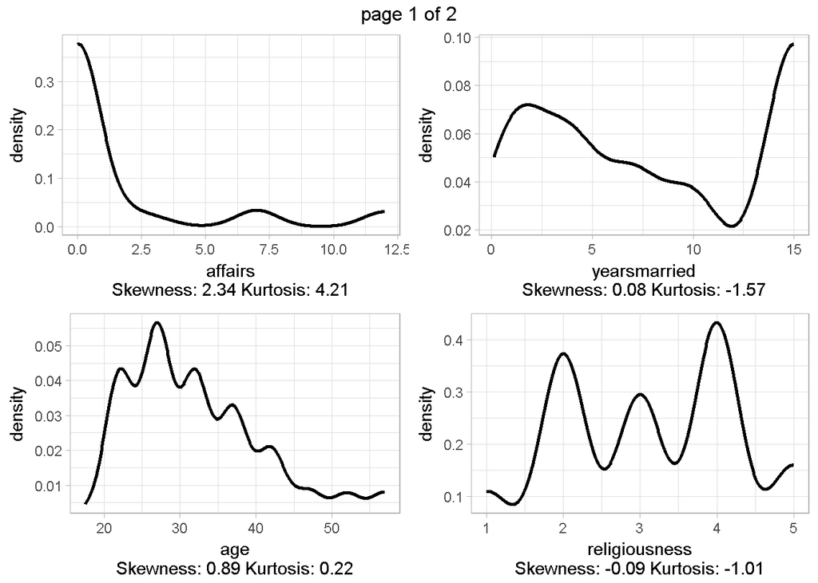

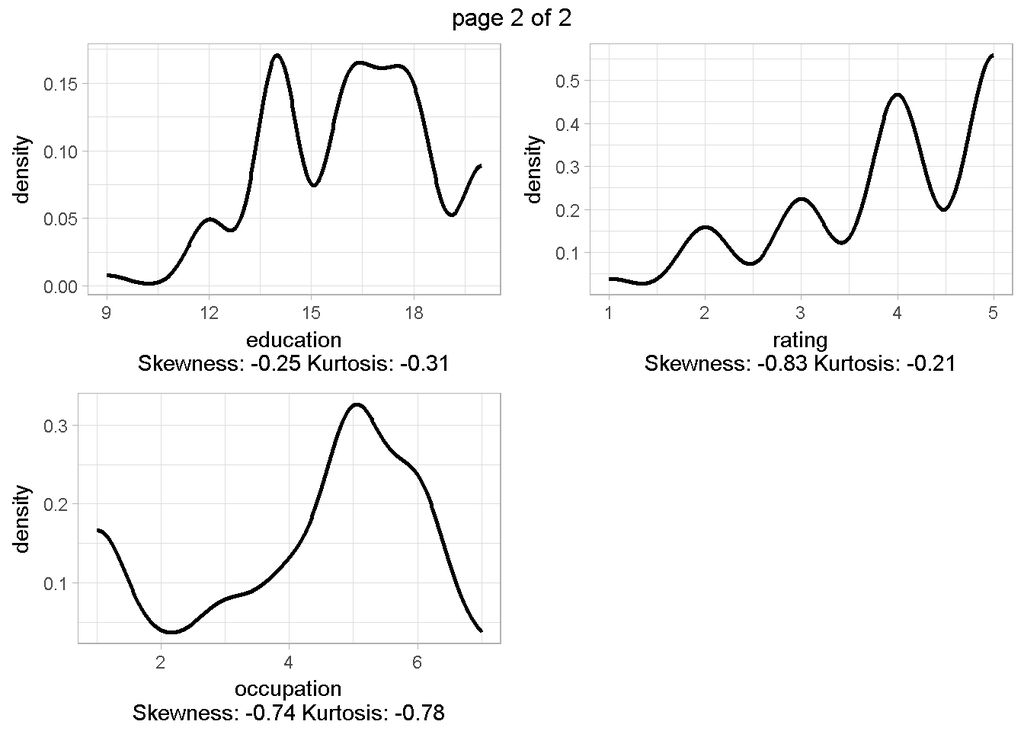

```r
# Nota: Variável excluída (se o valor único da variável for menor ou igual a 10 [im = 10])

ExpNumViz(Affairs,gp=NULL,Page=c(2,2),sample=8)
```

### Resumo de variáveis categóricas

#### Frequência para todas as variáveis independentes categóricas

```r
ExpCTable(Affairs,Target=NULL,margin=1,clim=10,nlim=NULL,round=2,bin=NULL,per=T)
```

```
##   Variable  Valid Frequency Percent CumPercent
## 1   gender female       315   52.41      52.41
## 2   gender   male       286   47.59     100.00
## 3   gender  TOTAL       601      NA         NA
## 4 children     no       171   28.45      28.45
## 5 children    yes       430   71.55     100.00
## 6 children  TOTAL       601      NA         NA
```

```r
# NA significa Not Applicable
```

#### Distribuições de variáveis categóricas

Gráficos de barra para todas as variáveis categóricas

```
## $`0`
```

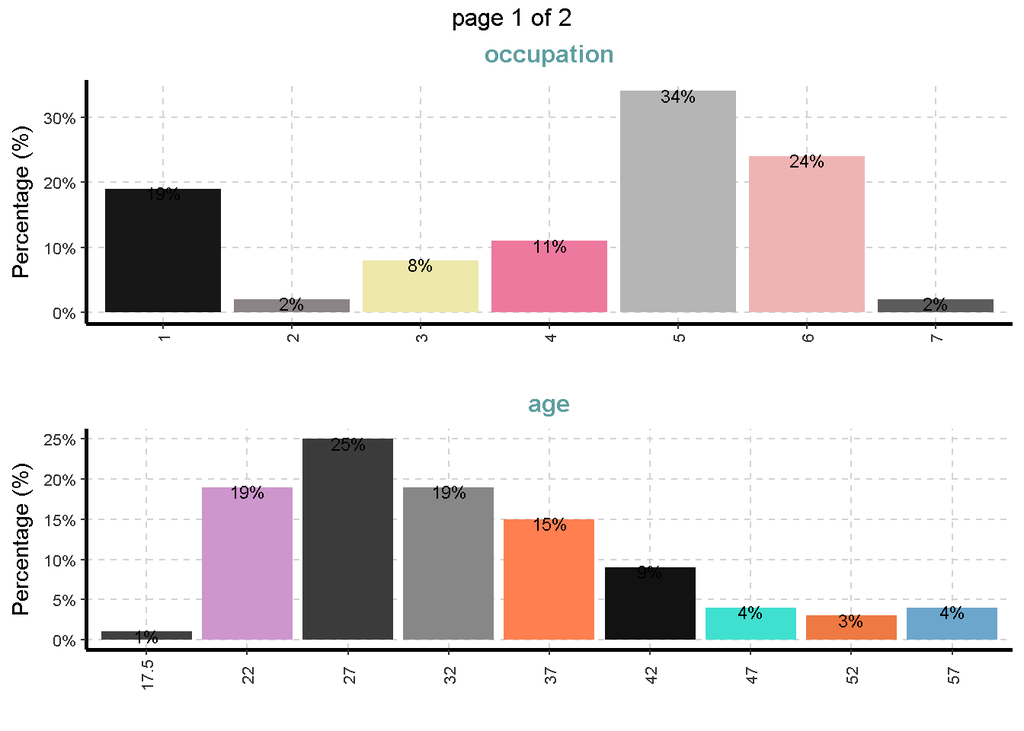

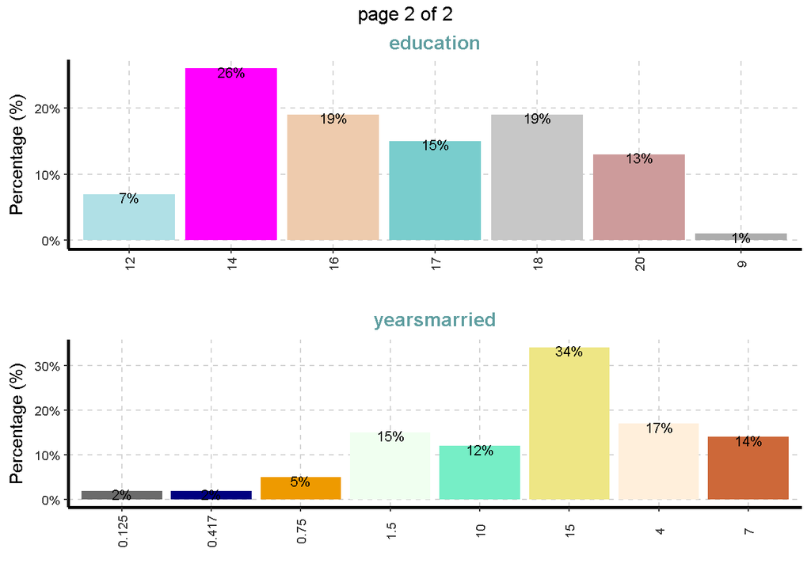

```r
ExpCatViz(Affairs,gp=NULL,fname=NULL,clim=10,margin=2,Page = c(2,1),sample=4)
```

## Exemplo para o caso 2: A variável de destino é contínua

### Variável alvo

#### Resumo da variável dependente contínua

Nome da variável - Affairs

```r
summary(Affairs[,"affairs"])
```

```
##    Min. 1st Qu.  Median    Mean 3rd Qu.    Max.
##   0.000   0.000   0.000   1.456   0.000  12.000
```

#### Resumo das variáveis numéricas

```r
ExpNumStat(Affairs,by="A",gp="affairs",Qnt=seq(0,1,0.1),MesofShape=1,Outlier=TRUE,round=2)
```

```
## Note: Target variable is continuous
## Summary statistics excluded group by statement
## Results generated with correlation value against target variable
```

```
##           Vname            Note  TN nNeg nZero nPos NegInf PosInf NA_Value
## 1       affairs Cor b/w affairs 601    0   451  150      0      0        0
## 2           age Cor b/w affairs 601    0     0  601      0      0        0
## 5     education Cor b/w affairs 601    0     0  601      0      0        0
## 6    occupation Cor b/w affairs 601    0     0  601      0      0        0
## 7        rating Cor b/w affairs 601    0     0  601      0      0        0
## 4 religiousness Cor b/w affairs 601    0     0  601      0      0        0
## 3  yearsmarried Cor b/w affairs 601    0     0  601      0      0        0
##   Per_of_Missing   min max  mean median   SD   CV IQR    0%  10%  20% 30%
## 1              0  0.00  12  1.46      0 3.30 2.27   0  0.00  0.0  0.0   0
## 2              0 17.50  57 32.49     32 9.29 0.29  10 17.50 22.0 22.0  27
## 5              0  9.00  20 16.17     16 2.40 0.15   4  9.00 14.0 14.0  14
## 6              0  1.00   7  4.19      5 1.82 0.43   3  1.00  1.0  2.0   4
## 7              0  1.00   5  3.93      4 1.10 0.28   2  1.00  2.0  3.0   4
## 4              0  1.00   5  3.12      3 1.17 0.37   2  1.00  2.0  2.0   2
## 3              0  0.12  15  8.18      7 5.57 0.68  11  0.12  1.5  1.5   4
##   40% 50% 60% 70% 80% 90% 100% LB.25% UB.75% nOutliers   cor
## 1   0   0   0   0   1   7   12    0.0    0.0       150  1.00
## 2  27  32  32  37  42  47   57   12.0   52.0        22  0.10
## 5  16  16  17  18  18  20   20    8.0   24.0         0  0.00
## 6   4   5   5   5   6   6    7   -1.5   10.5         0  0.05
## 7   4   4   4   5   5   5    5    0.0    8.0         0 -0.28
## 4   3   3   4   4   4   5    5   -1.0    7.0         0 -0.14
## 3   4   7  10  15  15  15   15  -12.5   31.5         0  0.19
```

```r
#Se a variável de destino for contínua, as estatísticas de resumo adicionarão a coluna de correlação (Correlação entre a variável de destino e todas as variáveis independentes)
```

#### Distribuições de variáveis numéricas

Representação gráfica de todas as variáveis numéricas

Variável dependente é affairs (contínuo).

```r
#Note: sample = 8 significa selecionado aleatoriamente 8 gráficos de dispersão
#Nota: nlim = 4 significa que a variável numérica com valor exclusivo é maior que 4

g=ExpNumViz(Affairs,gp="affairs",nlim=4,fname=NULL,col=NULL,Page=c(2,2),sample=8)
```

### Resumo de variáveis categóricas

Resumo de variáveis categóricas

frequência para todas as variáveis independentes categóricas por descretized Affairs

```r
##bin=4, descretized 4 categories based on quantiles
Affairs$daffairs = ifelse(Affairs$affairs!=0,1,0)
Affairs=Affairs[,-1]
ExpCTable(Affairs,Target="daffairs",margin=1,clim=10,nlim=NULL,round=2,bin=NULL,per=F)
```

```
##   VARIABLE CATEGORY daffairs:0 daffairs:1 TOTAL
## 1   gender   female        243         72   315
## 2   gender     male        208         78   286
## 3   gender    TOTAL        451        150   601
## 4 children       no        144         27   171
## 5 children      yes        307        123   430
## 6 children    TOTAL        451        150   601
## 7 daffairs        0        451          0   451
## 8 daffairs        1          0        150   150
## 9 daffairs    TOTAL        451        150   601
```

### Exemplo para o caso 3: a variável de destino é categórica

Variável alvo

#### Resumo da variável dependente categórica

Nome da variável - affairs Descrição variável - Se teve affairs ou nao

#### Resumo das variáveis numéricas

Resumo de todas as variáveis numéricas

```r
ExpNumStat(Affairs,by="GA",gp="daffairs",Qnt=seq(0,1,0.1),MesofShape=2,Outlier=TRUE,round=2)
```

```
##            Vname        Group  TN nNeg nZero nPos NegInf PosInf NA_Value
## 1            age daffairs:All 601    0     0  601      0      0        0
## 7            age   daffairs:0 451    0     0  451      0      0        0
## 13           age   daffairs:1 150    0     0  150      0      0        0
## 4      education daffairs:All 601    0     0  601      0      0        0
## 10     education   daffairs:0 451    0     0  451      0      0        0
## 16     education   daffairs:1 150    0     0  150      0      0        0
## 5     occupation daffairs:All 601    0     0  601      0      0        0
## 11    occupation   daffairs:0 451    0     0  451      0      0        0
## 17    occupation   daffairs:1 150    0     0  150      0      0        0
## 6         rating daffairs:All 601    0     0  601      0      0        0
## 12        rating   daffairs:0 451    0     0  451      0      0        0
## 18        rating   daffairs:1 150    0     0  150      0      0        0
## 3  religiousness daffairs:All 601    0     0  601      0      0        0
## 9  religiousness   daffairs:0 451    0     0  451      0      0        0
```

[output cut: 61 more lines]

#### Distribuições de variáveis numéricas

Box plots para todas as variáveis numéricas vs variável dependente categórica - Comparação bivariada apenas com categorias

Boxplot para todos os atributos numéricos por cada categoria de affair

```
## $`0`
```

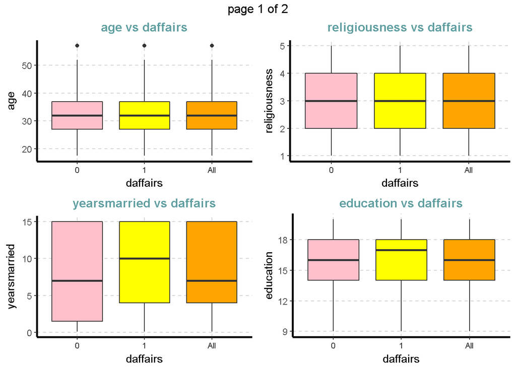

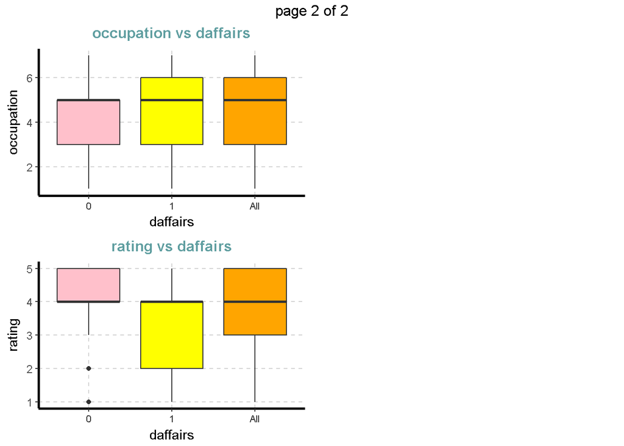

```r
ExpNumViz(Affairs,gp="daffairs",type=1,nlim=NULL,fname=NULL,col=c("pink","yellow","orange"),Page=c(2,2),sample=8)
```

#### Resumo das variáveis categóricas

Tabulação cruzada com variável de destino

Tabelas customizadas entre todas as variáveis independentes categóricas e a variável de destino affairs

```r
ExpCTable(Affairs,Target="daffairs",margin=1,clim=10,nlim=NULL,round=2,bin=NULL,per=F)
```

```
##   VARIABLE CATEGORY daffairs:0 daffairs:1 TOTAL
## 1   gender   female        243         72   315
## 2   gender     male        208         78   286
## 3   gender    TOTAL        451        150   601
## 4 children       no        144         27   171
## 5 children      yes        307        123   430
## 6 children    TOTAL        451        150   601
## 7 daffairs        0        451          0   451
## 8 daffairs        1          0        150   150
## 9 daffairs    TOTAL        451        150   601
```

#### Valor da informação

```r
ExpCatStat(Affairs,Target="daffairs",result = "IV")
```

```
##         Variable   Target  Class Out_1 Out_0 TOTAL Per_1 Per_0  Odds
## 1         gender daffairs female    72   243   315 0.480 0.539 0.891
## 2         gender daffairs   male    78   208   286 0.520 0.461 1.128
## 3       children daffairs     no    27   144   171 0.180 0.319 0.564
## 4       children daffairs    yes   123   307   430 0.820 0.681 1.204
## 5            age daffairs   17.5     3     3     6 0.020 0.007 2.857
## 6            age daffairs     22    16   101   117 0.107 0.224 0.478
## 7            age daffairs     27    36   117   153 0.240 0.259 0.927
## 8            age daffairs     32    38    77   115 0.253 0.171 1.480
## 9            age daffairs     37    23    65    88 0.153 0.144 1.062
## 10           age daffairs     42    18    38    56 0.120 0.084 1.429
## 11           age daffairs     47     7    16    23 0.047 0.035 1.343
## 12           age daffairs     52     6    15    21 0.040 0.033 1.212
## 13           age daffairs     57     3    19    22 0.020 0.042 0.476
## 14  yearsmarried daffairs  0.125     1    10    11 0.007 0.022 0.318
```

[output cut: 77 more lines]

#### Teste Estatistico

```r
ExpCatStat(Affairs,Target="daffairs",result = "Stat")
```

```
##        Variable   Target Unique Chi-squared p-value df IV Value
## 1        gender daffairs      2       1.334   0.248  1    0.014
## 2      children daffairs      2      10.055   0.002  1    0.106
## 3           age daffairs      9      17.771   0.023  8    0.168
## 4  yearsmarried daffairs      8      17.177   0.016  7    0.183
## 5 religiousness daffairs      5      19.354   0.001  4    0.166
## 6     education daffairs      7       7.057   0.316  6    0.066
## 7    occupation daffairs      7       6.718   0.348  6    0.058
## 8        rating daffairs      5      41.433       0  4    0.347
##            Pred Power
## 1      Not Predictive
## 2   Medium Predictive
## 3   Medium Predictive
## 4   Medium Predictive
## 5   Medium Predictive
## 6 Somewhat Predictive
## 7 Somewhat Predictive
## 8   Highly Predictive
```

#### Distribuições de variáveis categóricas

```
## $`0`
```

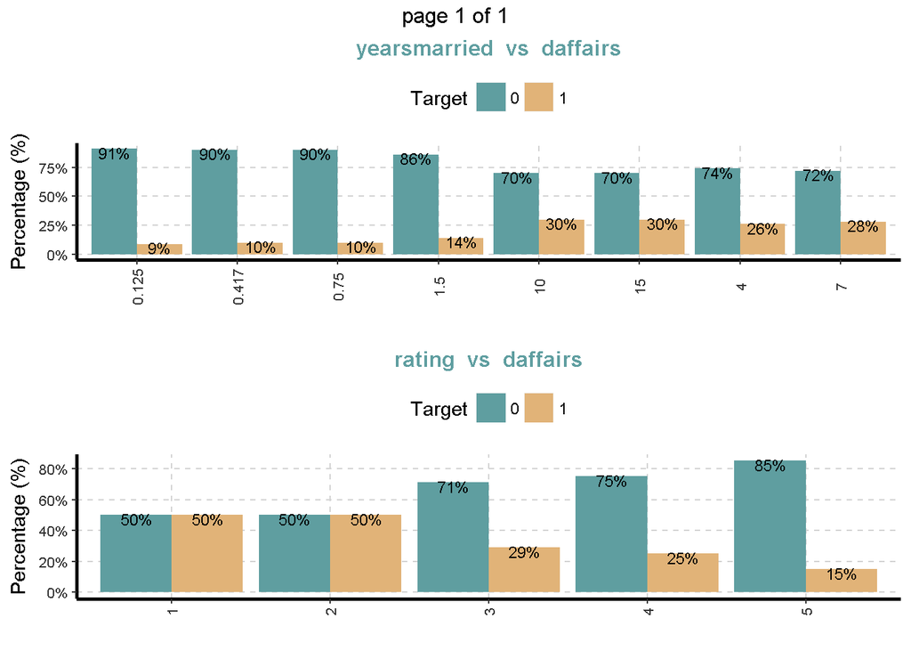

```r
ExpCatViz(Affairs,gp="daffairs",fname=NULL,clim=10,col=NULL,margin=2,Page = c(2,1),sample=2)
```

# Ajuste do modelo linear

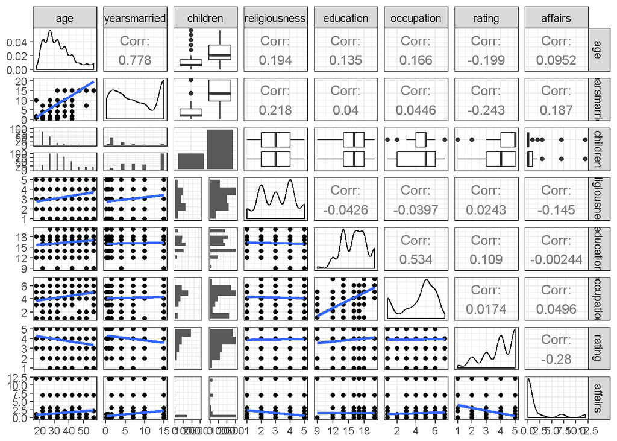

```r
source("functions.R")
suppressMessages(library(ggplot2))
suppressMessages(library(dplyr))
suppressMessages(library(GGally))
data("Affairs")
#Correlaçoes cruzadas
Affairs%>%
  select(age:rating,affairs)%>%
ggpairs(lower = list(continuous = my_fn,combo=wrap("facethist", binwidth=1),
                                       continuous=wrap(my_bin, binwidth=0.25)),aes(fill=affairs))+theme_bw()
```

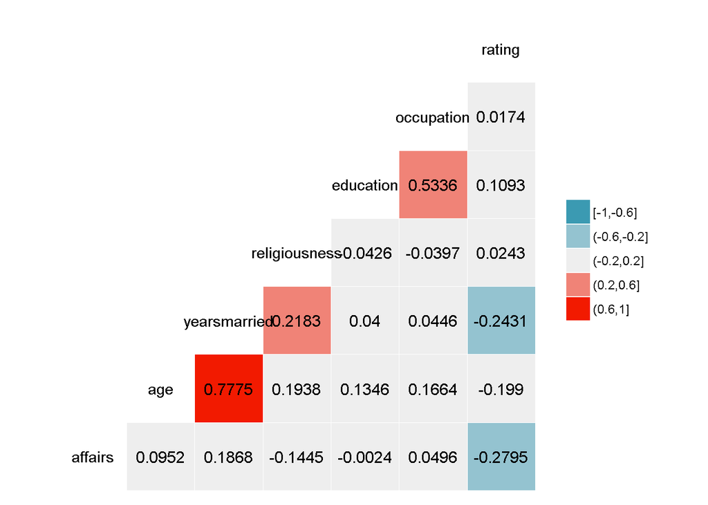

```r
ggcorr(Affairs,label = T,nbreaks = 5,label_round = 4)
```

# Modelo de regressão linear usando stepwiseAIC

```r
suppressMessages(library(caret))
set.seed(123)
index <- sample(1:2,nrow(Affairs),replace=T,prob=c(0.7,0.3))
train = Affairs[index==1,]
test = Affairs[index==2,]

# Set up training control
fitControl <- trainControl(method = "repeatedcv",   # 10fold cross validation
                     number = 10, repeats=5,                            # do 5 repititions of cv
                     allowParallel = TRUE)

# Use the expand.grid to specify the search space
# Note that the default search grid selects multiple values of each tuning parameter

# Support Vector Machines
set.seed(825)
lmFit <- train(affairs ~ ., data = train,
                method = "lmStepAIC",
                trControl = fitControl,
                preProc = c("center", "scale"),trace=F)
summary(lmFit)
```

```
##
## Call:
## lm(formula = .outcome ~ age + yearsmarried + religiousness +
##     occupation + rating, data = dat)
##
## Residuals:
##     Min      1Q  Median      3Q     Max
## -5.2617 -1.8178 -0.7493  0.3806 11.0902
##
## Coefficients:
##               Estimate Std. Error t value             Pr(>|t|)
## (Intercept)     1.4612     0.1505   9.710 < 0.0000000000000002 ***
## age            -0.5975     0.2451  -2.438             0.015176 *
## yearsmarried    1.1431     0.2472   4.624           0.00000501 ***
## religiousness  -0.5576     0.1564  -3.566             0.000405 ***
## occupation      0.3611     0.1557   2.319             0.020893 *
## rating         -0.7546     0.1583  -4.767           0.00000258 ***
## ---
## Signif. codes:  0 '***' 0.001 '**' 0.01 '*' 0.05 '.' 0.1 ' ' 1
##
## Residual standard error: 3.102 on 419 degrees of freedom
## Multiple R-squared:  0.1471, Adjusted R-squared:  0.1369
## F-statistic: 14.45 on 5 and 419 DF,  p-value: 0.0000000000004552
```

Selecionando apenas as variaveis

```r
train=as.data.frame(train[,c(1,3,4,6,8,9)])
test=as.data.frame(test[,c(1,3,4,6,8,9)])
```

# Diagnóstico do modelo

## Avaliando residuos

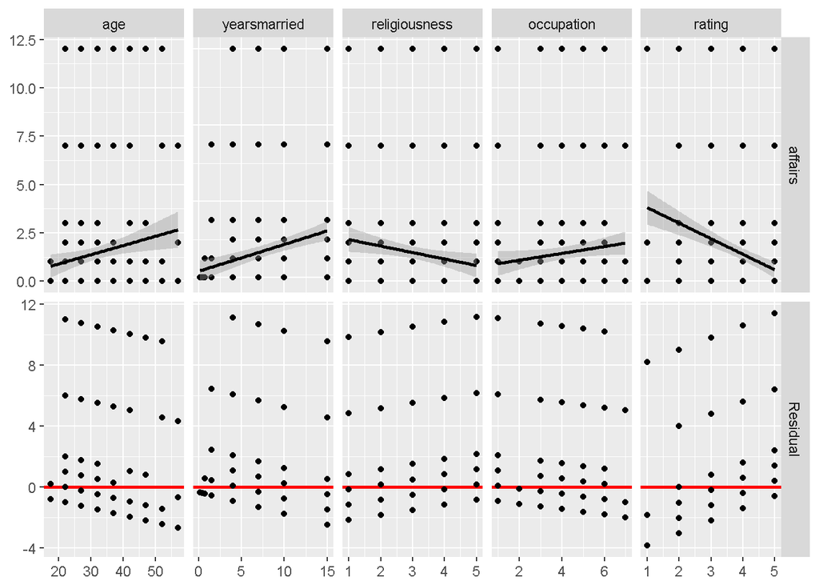

```r
# calculate all residuals prior to display
residuals <- lapply(train[2:ncol(train)], function(x) {
  summary(lm(affairs ~ x, data = train))$residuals
})

# add a 'fake' column
train$Residual <- seq_len(nrow(train))

# calculate a consistent y range for all residuals
y_range <- range(unlist(residuals))

# plot the data
ggduo(
  train,
  2:6, c(1,7),
  types = list(continuous = lm_or_resid)
)
```

```r
train=train%>%
  select(-Residual)
```

## Inferencia dos parametros

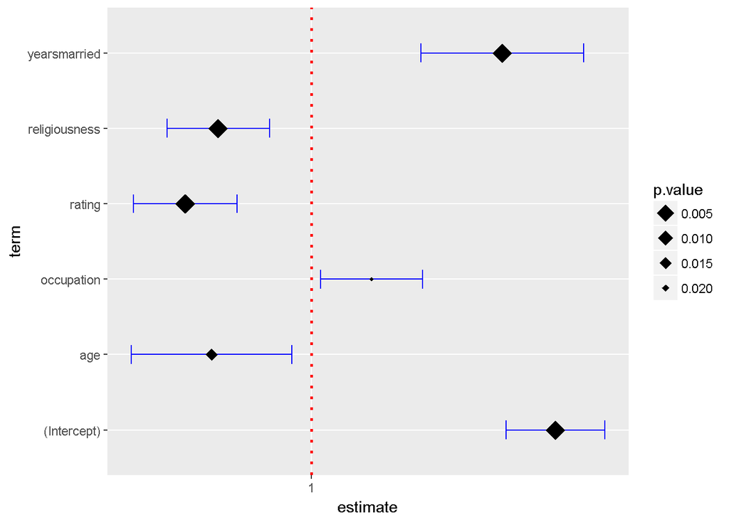

```r
ggcoef(
  lmFit$finalModel,                      #O modelo a ser conferido
  exponentiate = TRUE,          #Para avaliar o modelo logístico
  vline_color = "red",          #Reta em zero
  #vline_linetype =  "solid",   #Altera a linha de referência
  errorbar_color = "blue",      #Cor da barra de erros
  errorbar_height = .25,
  shape = 18,                   #Altera o formato dos pontos centrais
  #size=3,                      #Altera o tamanho do ponto
  color="black",                #Altera a cor do ponto
  mapping = aes(x = estimate, y = term, size = p.value))+
  scale_size_continuous(trans = "reverse") #Essa linha faz com que inverta o tamanho
```

## Residuos e medidas de influencia

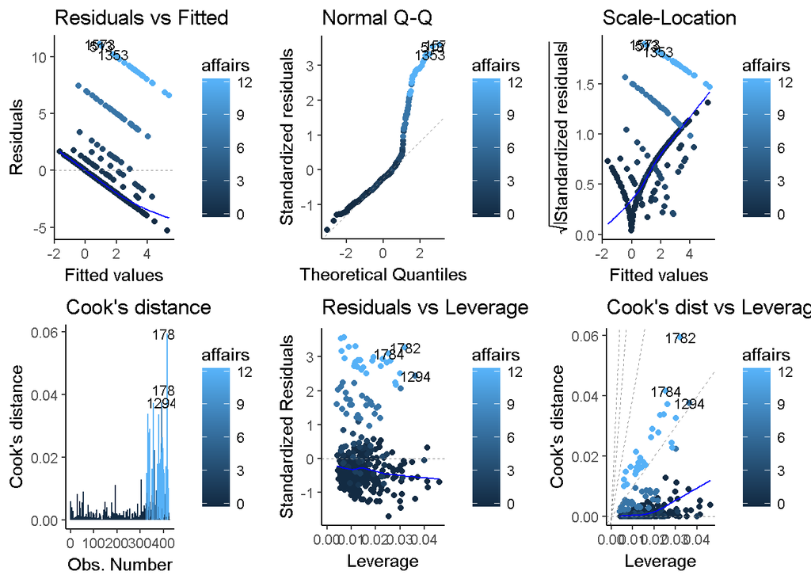

```r
suppressMessages(library(ggfortify))

autoplot(lmFit$finalModel, which = 1:6, data = train,
         colour = 'affairs', label.size = 3,
         ncol = 3)+theme_classic()
```

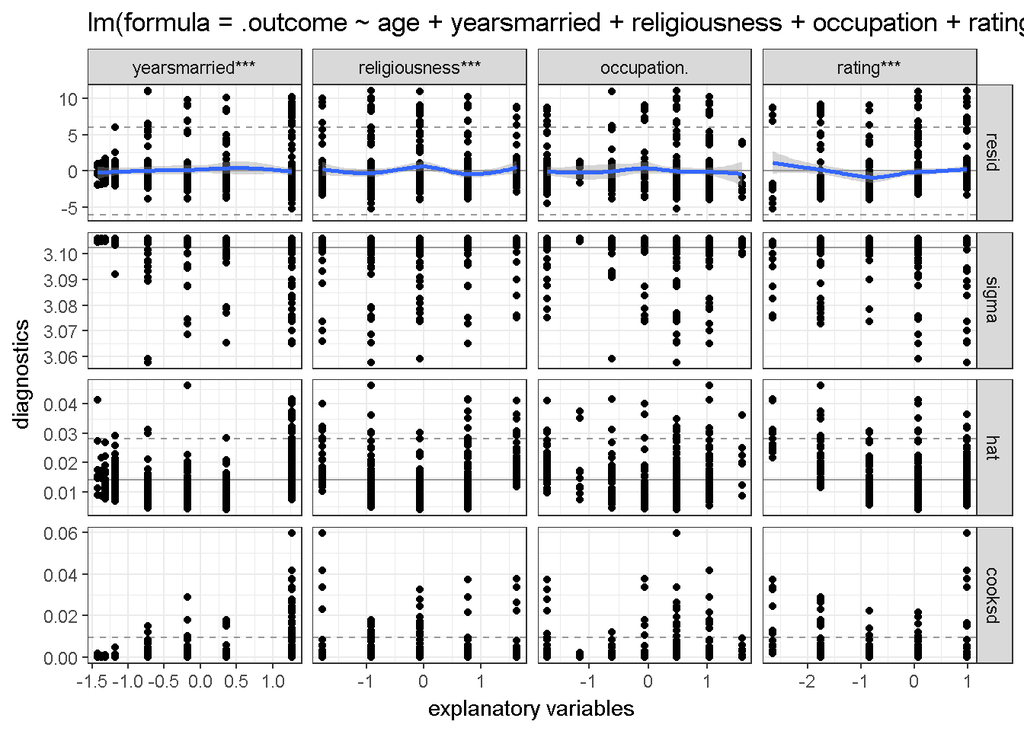

```r
# look at model diagnostics
ggnostic(lmFit$finalModel)+theme_bw()
```

# Machine Learning

```r
Affairs$affairs = ifelse(Affairs$affairs!=0,1,0)
suppressMessages(library(FSelector))
chi.squared(affairs~.,Affairs)
```

```
##               attr_importance
## gender              0.1006478
## age                 0.0000000
## yearsmarried        0.0000000
## children            0.1441845
## religiousness       0.0000000
## education           0.0000000
## occupation          0.0000000
## rating              0.0000000
```

```r
suppressMessages(library(caret))
suppressMessages(library(doParallel))
Affairs$affairs=as.factor(Affairs$affairs)
levels(Affairs$affairs)=c("Nao","Sim")

index <- sample(1:2,nrow(Affairs),replace=T,prob=c(0.7,0.3))
train = Affairs[index==1,]
test = Affairs[index==2,]
```

```r
# Set up training control
fitctrl <- trainControl(method = "repeatedcv",   # 10fold cross validation
                     number = 5,                            # do 5 repititions of cv
                     # summaryFunction=twoClassSummary, # Use AUC to pick the best model
                     classProbs=TRUE,
                     allowParallel = TRUE)

# Use the expand.grid to specify the search space
# Note that the default search grid selects multiple values of each tuning parameter
```

[output not shown]

[output not shown]

[output not shown]

[output not shown]

[output not shown]

```r
svmFit
```

[output not shown]

```r
nnetFit
```

```
## Neural Network
##
## 185 samples
##   4 predictor
##   2 classes: 'Nao', 'Sim'
##
## Pre-processing: centered (4), scaled (4)
## Resampling: Cross-Validated (10 fold, repeated 5 times)
## Summary of sample sizes: 166, 166, 167, 166, 166, 166, ...
## Resampling results across tuning parameters:
##
##   size  decay   Accuracy   Kappa
##   1     0.0000  0.7132061  0.07109990
##   1     0.0001  0.7212625  0.02009079
##   1     0.1000  0.7212040  0.07492532
##   3     0.0000  0.7077159  0.11550363
##   3     0.0001  0.7148228  0.14928021
##   3     0.1000  0.7344272  0.12608954
##   5     0.0000  0.6847712  0.10398491
##   5     0.0001  0.7033161  0.13870914
##   5     0.1000  0.7302167  0.12456458
##
## Accuracy was used to select the optimal model using the largest value.
## The final values used for the model were size = 3 and decay = 0.1.
```

```r
gbmFit
```

```
## Stochastic Gradient Boosting
##
## 185 samples
##   4 predictor
##   2 classes: 'Nao', 'Sim'
##
## Pre-processing: centered (4), scaled (4)
## Resampling: Cross-Validated (10 fold, repeated 5 times)
## Summary of sample sizes: 166, 166, 167, 166, 166, 166, ...
## Resampling results across tuning parameters:
##
##   interaction.depth  n.trees  Accuracy   Kappa
##   1                   50      0.7451221  0.1175066
##   1                  100      0.7376367  0.1250095
##   1                  150      0.7331854  0.1488015
##   2                   50      0.7279291  0.1339134
##   2                  100      0.7336877  0.1720894
##   2                  150      0.7367871  0.1898993
##   3                   50      0.7230891  0.1454703
##   3                  100      0.7261369  0.1737184
##   3                  150      0.7316409  0.1924118
##
## Tuning parameter 'shrinkage' was held constant at a value of 0.1
##
## Tuning parameter 'n.minobsinnode' was held constant at a value of 10
## Accuracy was used to select the optimal model using the largest value.
## The final values used for the model were n.trees = 50, interaction.depth
##  = 1, shrinkage = 0.1 and n.minobsinnode = 10.
```

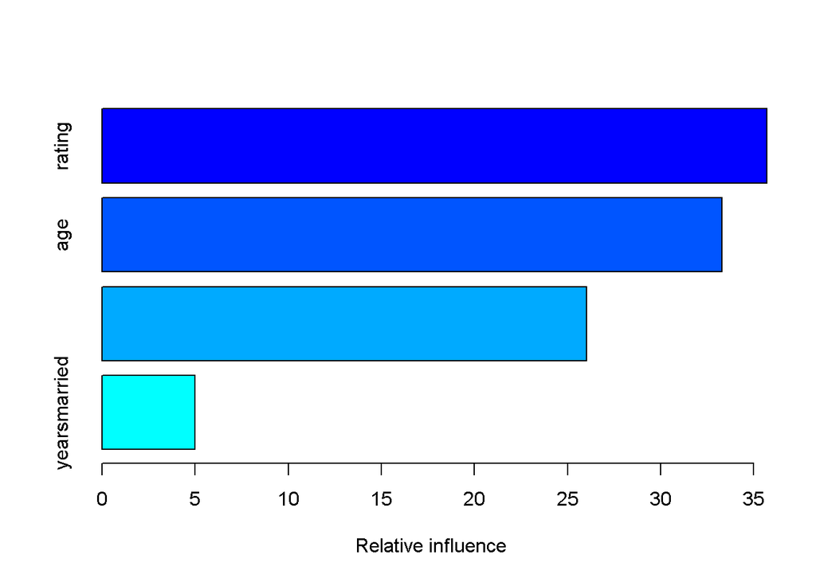

```
##                         var   rel.inf
## rating               rating 35.699873
## age                     age 33.285361
## religiousness religiousness 26.016632
## yearsmarried   yearsmarried  4.998134
```

```r
summary(gbmFit$finalModel)
```

```r
glmFit
```

```
## Generalized Linear Model
##
## 185 samples
##   4 predictor
##   2 classes: 'Nao', 'Sim'
##
## Pre-processing: centered (4), scaled (4)
## Resampling: Cross-Validated (10 fold, repeated 5 times)
## Summary of sample sizes: 166, 166, 167, 166, 166, 166, ...
## Resampling results:
##
##   Accuracy   Kappa
##   0.7331923  0.09753198
```

```r
summary(glmFit$finalModel)
```

```
##
## Call:
## NULL
##
## Deviance Residuals:
##     Min       1Q   Median       3Q      Max
## -1.5863  -0.7681  -0.5810   1.0014   2.2310
##
## Coefficients:
##               Estimate Std. Error z value       Pr(>|z|)
## (Intercept)    -1.1783     0.1867  -6.311 0.000000000277 ***
## age            -0.3297     0.2870  -1.149        0.25050
## yearsmarried    0.6104     0.2813   2.170        0.02999 *
## religiousness  -0.3943     0.1996  -1.975        0.04825 *
## rating         -0.4796     0.1811  -2.648        0.00809 **
## ---
## Signif. codes:  0 '***' 0.001 '**' 0.01 '*' 0.05 '.' 0.1 ' ' 1
##
## (Dispersion parameter for binomial family taken to be 1)
##
##     Null deviance: 211.82  on 184  degrees of freedom
## Residual deviance: 193.04  on 180  degrees of freedom
## AIC: 203.04
##
## Number of Fisher Scoring iterations: 4
```

```r
rfFit
```

```
## Random Forest
##
## 185 samples
##   4 predictor
##   2 classes: 'Nao', 'Sim'
##
## Pre-processing: centered (4), scaled (4)
## Resampling: Cross-Validated (10 fold, repeated 5 times)
## Summary of sample sizes: 166, 166, 167, 166, 166, 166, ...
## Resampling results across tuning parameters:
##
##   mtry  Accuracy   Kappa
##   2     0.7333746  0.1658566
##   3     0.7158239  0.1663058
##   4     0.7114379  0.1562116
##
## Accuracy was used to select the optimal model using the largest value.
## The final value used for the model was mtry = 2.
```

```r
rfFit$finalModel
```

```
##
## Call:
##  randomForest(x = x, y = y, mtry = param$mtry)
##                Type of random forest: classification
##                      Number of trees: 500
## No. of variables tried at each split: 2
##
##         OOB estimate of  error rate: 28.11%
## Confusion matrix:
##     Nao Sim class.error
## Nao 123  14   0.1021898
## Sim  38  10   0.7916667
```

```r
summary(rfFit$finalModel)
```

```
##                 Length Class      Mode
## call               4   -none-     call
## type               1   -none-     character
## predicted        185   factor     numeric
## err.rate        1500   -none-     numeric
## confusion          6   -none-     numeric
## votes            370   matrix     numeric
## oob.times        185   -none-     numeric
## classes            2   -none-     character
## importance         4   -none-     numeric
## importanceSD       0   -none-     NULL
## localImportance    0   -none-     NULL
## proximity          0   -none-     NULL
## ntree              1   -none-     numeric
## mtry               1   -none-     numeric
## forest            14   -none-     list
## y                185   factor     numeric
## test               0   -none-     NULL
## inbag              0   -none-     NULL
## xNames             4   -none-     character
## problemType        1   -none-     character
## tuneValue          1   data.frame list
## obsLevels          2   -none-     character
## param              0   -none-     list
```

```r
#Given these models, can we make statistical statements about their performance differences? To do this, we first collect the resampling results using resamples.
resamps <- resamples(list(SVM = svmFit,
                          nnet = nnetFit,
                          GBM = gbmFit,
                          glmFit=glmFit,
                          rfFit = rfFit))
resamps
```

```
##
## Call:
## resamples.default(x = list(SVM = svmFit, nnet = nnetFit, GBM =
##  gbmFit, glmFit = glmFit, rfFit = rfFit))
##
## Models: SVM, nnet, GBM, glmFit, rfFit
## Number of resamples: 50
## Performance metrics: Accuracy, Kappa
## Time estimates for: everything, final model fit
```

```r
summary(resamps)
```

```
##
## Call:
## summary.resamples(object = resamps)
##
## Models: SVM, nnet, GBM, glmFit, rfFit
## Number of resamples: 50
##
## Accuracy
##             Min.   1st Qu.    Median      Mean   3rd Qu.      Max. NA's
## SVM    0.7222222 0.7368421 0.7368421 0.7407362 0.7368421 0.7777778    0
## nnet   0.6111111 0.7099673 0.7368421 0.7344272 0.7777778 0.8823529    0
## GBM    0.5555556 0.7222222 0.7368421 0.7451221 0.7894737 0.8421053    0
## glmFit 0.5789474 0.6842105 0.7368421 0.7331923 0.7865497 0.8888889    0
## rfFit  0.5789474 0.6842105 0.7368421 0.7333746 0.7865497 0.8888889    0
##
## Kappa
##              Min.     1st Qu.     Median       Mean   3rd Qu.      Max.
## SVM     0.0000000  0.00000000 0.00000000 0.00000000 0.0000000 0.0000000
## nnet   -0.2352941  0.00000000 0.15094340 0.12608954 0.2682496 0.6046512
## GBM    -0.2857143  0.00000000 0.03278689 0.11750660 0.2692308 0.4955752
## glmFit -0.2459016 -0.09615385 0.03278689 0.09753198 0.2682496 0.6842105
## rfFit  -0.1769912  0.00000000 0.15094340 0.16585655 0.2748092 0.6842105
##        NA's
## SVM       0
## nnet      0
## GBM       0
## glmFit    0
## rfFit     0
```

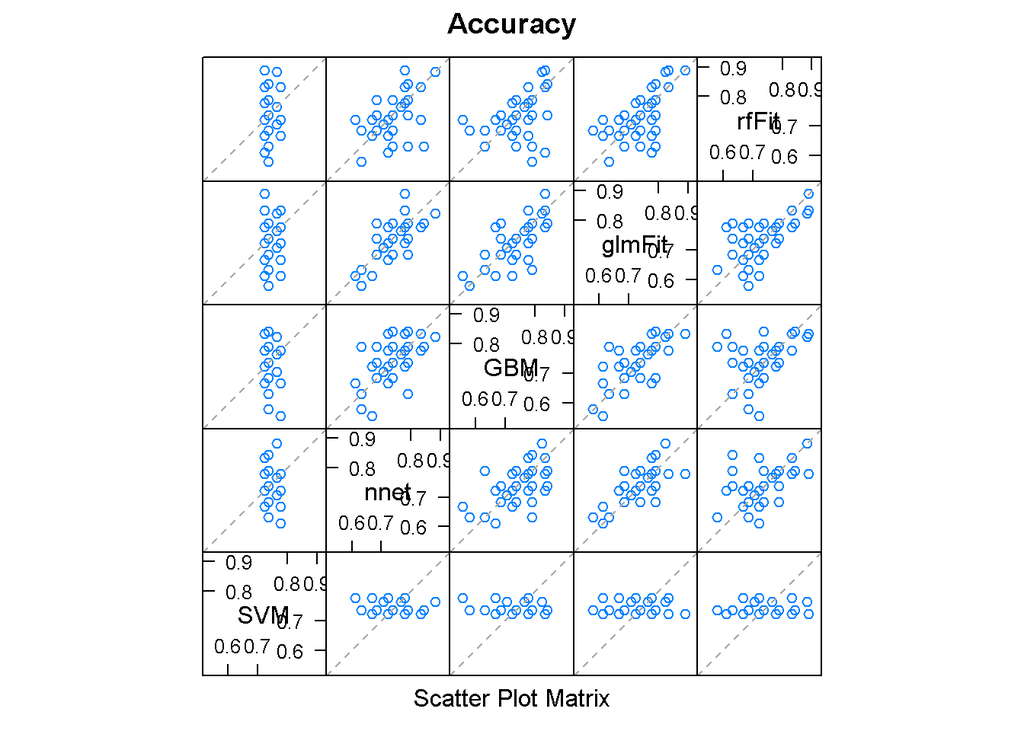

```r
splom(resamps)
```

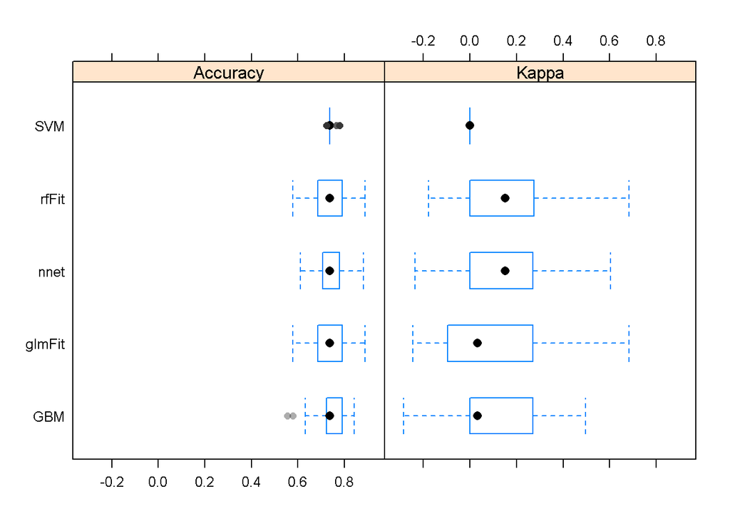

```r
theme1 <- trellis.par.get()
theme1$plot.symbol$col = rgb(.2, .2, .2, .4)
theme1$plot.symbol$pch = 16
theme1$plot.line$col = rgb(1, 0, 0, .7)
theme1$plot.line$lwd <- 2
trellis.par.set(theme1)
bwplot(resamps, layout = c(2, 1))
```

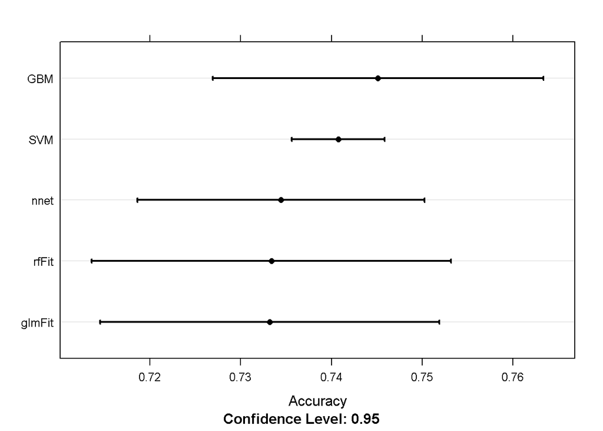

```r
trellis.par.set(caretTheme())
dotplot(resamps, metric = "Accuracy")
```

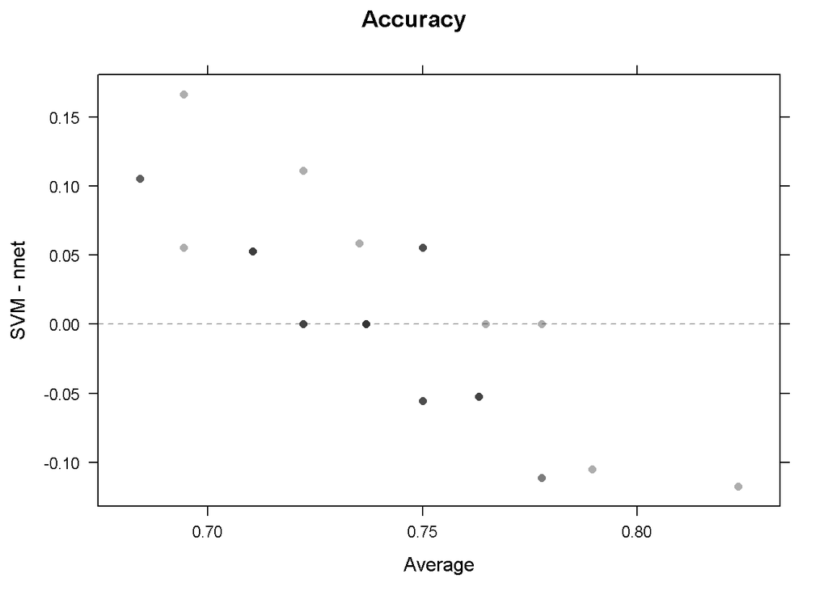

```r
trellis.par.set(theme1)
xyplot(resamps, what = "BlandAltman")
```

```r
confusionMatrix(test[,1],predict(svmFit,test[,-1]%>%select(age,yearsmarried,religiousness,rating)))
```

```
## Confusion Matrix and Statistics
##
##           Reference
## Prediction Nao Sim
##        Nao 137   0
##        Sim  48   0
##
##                Accuracy : 0.7405
##                  95% CI : (0.6711, 0.8021)
##     No Information Rate : 1
##     P-Value [Acc > NIR] : 1
##
##                   Kappa : 0
##  Mcnemar's Test P-Value : 0.0000000000117
##
##             Sensitivity : 0.7405
##             Specificity :     NA
##          Pos Pred Value :     NA
##          Neg Pred Value :     NA
##              Prevalence : 1.0000
##          Detection Rate : 0.7405
##    Detection Prevalence : 0.7405
##       Balanced Accuracy :     NA
##
##        'Positive' Class : Nao
##
```

```r
confusionMatrix(test[,1],predict(nnetFit,test[,-1]%>%select(age,yearsmarried,religiousness,rating)))
```

```
## Confusion Matrix and Statistics
##
##           Reference
## Prediction Nao Sim
##        Nao 131   6
##        Sim  38  10
##
##                Accuracy : 0.7622
##                  95% CI : (0.6942, 0.8216)
##     No Information Rate : 0.9135
##     P-Value [Acc > NIR] : 1
##
##                   Kappa : 0.21
##  Mcnemar's Test P-Value : 0.000002962
##
##             Sensitivity : 0.7751
##             Specificity : 0.6250
##          Pos Pred Value : 0.9562
##          Neg Pred Value : 0.2083
##              Prevalence : 0.9135
##          Detection Rate : 0.7081
##    Detection Prevalence : 0.7405
##       Balanced Accuracy : 0.7001
##
##        'Positive' Class : Nao
##
```

```r
confusionMatrix( test[,1],predict(gbmFit,test[,-1]%>%select(age,yearsmarried,religiousness,rating)))
```

```
## Confusion Matrix and Statistics
##
##           Reference
## Prediction Nao Sim
##        Nao 135   2
##        Sim  37  11
##
##                Accuracy : 0.7892
##                  95% CI : (0.7233, 0.8456)
##     No Information Rate : 0.9297
##     P-Value [Acc > NIR] : 1
##
##                   Kappa : 0.2812
##  Mcnemar's Test P-Value : 0.00000005199
##
##             Sensitivity : 0.7849
##             Specificity : 0.8462
##          Pos Pred Value : 0.9854
##          Neg Pred Value : 0.2292
##              Prevalence : 0.9297
##          Detection Rate : 0.7297
##    Detection Prevalence : 0.7405
##       Balanced Accuracy : 0.8155
##
##        'Positive' Class : Nao
##
```

```r
confusionMatrix( test[,1],predict(glmFit,test[,-1]%>%select(age,yearsmarried,religiousness,rating)))
```

```
## Confusion Matrix and Statistics
##
##           Reference
## Prediction Nao Sim
##        Nao 133   4
##        Sim  41   7
##
##                Accuracy : 0.7568
##                  95% CI : (0.6884, 0.8167)
##     No Information Rate : 0.9405
##     P-Value [Acc > NIR] : 1
##
##                   Kappa : 0.1556
##  Mcnemar's Test P-Value : 0.00000008025
##
##             Sensitivity : 0.7644
##             Specificity : 0.6364
##          Pos Pred Value : 0.9708
##          Neg Pred Value : 0.1458
##              Prevalence : 0.9405
##          Detection Rate : 0.7189
##    Detection Prevalence : 0.7405
##       Balanced Accuracy : 0.7004
##
##        'Positive' Class : Nao
##
```

```r
confusionMatrix( test[,1],predict(rfFit,test[,-1]%>%select(age,yearsmarried,religiousness,rating)))
```

```
## Confusion Matrix and Statistics
##
##           Reference
## Prediction Nao Sim
##        Nao 135   2
##        Sim  13  35
##
##                Accuracy : 0.9189
##                  95% CI : (0.8698, 0.9539)
##     No Information Rate : 0.8
##     P-Value [Acc > NIR] : 0.000007214
##
##                   Kappa : 0.772
##  Mcnemar's Test P-Value : 0.009823
##
##             Sensitivity : 0.9122
##             Specificity : 0.9459
##          Pos Pred Value : 0.9854
##          Neg Pred Value : 0.7292
##              Prevalence : 0.8000
##          Detection Rate : 0.7297
##    Detection Prevalence : 0.7405
##       Balanced Accuracy : 0.9291
##
##        'Positive' Class : Nao
##
```

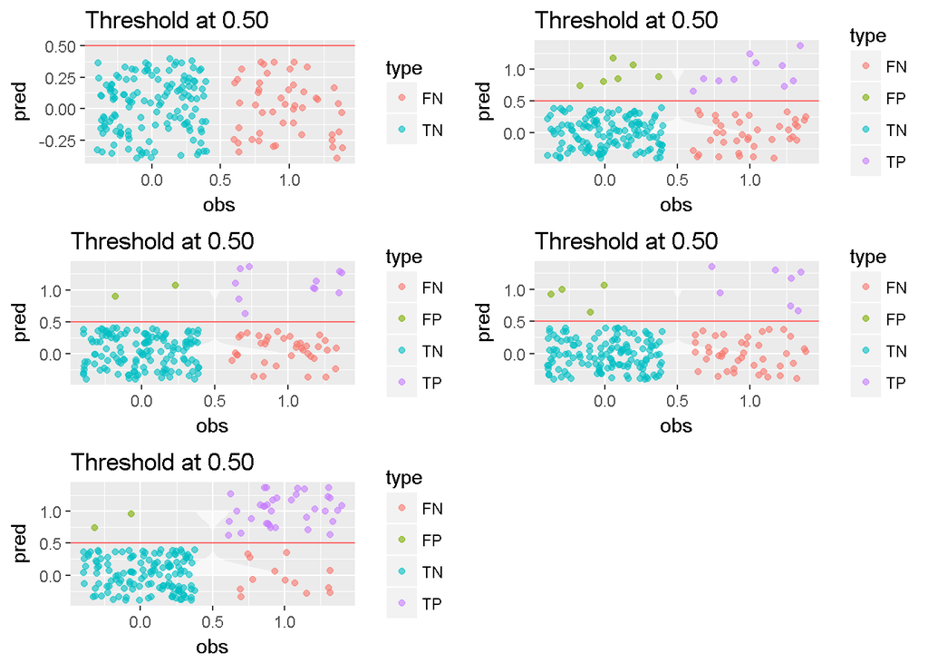

```r
dfSVM = as.data.frame(cbind(obs=test[,1],pred=predict(svmFit,test[,-1]%>%select(age,yearsmarried,religiousness,rating))))-1
dfNNET = as.data.frame(cbind(obs=test[,1],pred=predict(nnetFit,test[,-1]%>%select(age,yearsmarried,religiousness,rating))))-1
dfGBM = as.data.frame(cbind(obs=test[,1],pred=predict(gbmFit,test[,-1]%>%select(age,yearsmarried,religiousness,rating))))-1
dfGLM = as.data.frame(cbind(obs= test[,1],pred=predict(glmFit,test[,-1]%>%select(age,yearsmarried,religiousness,rating))))-1
dfRF = as.data.frame(cbind(obs= test[,1],pred=predict(rfFit,test[,-1]%>%select(age,yearsmarried,religiousness,rating))))-1


g1=plot_pred_type_distribution(dfSVM,0.5)
g2=plot_pred_type_distribution(dfNNET,0.5)
g3=plot_pred_type_distribution(dfGBM,0.5)
g4=plot_pred_type_distribution(dfGLM,0.5)
g5=plot_pred_type_distribution(dfRF,0.5)

gridExtra::grid.arrange(g1,g2,g3,g4,g5,ncol=2)
```

https://github.com/joyofdata/joyofdata-articles/blob/master/roc-auc/calculate_roc.R#L1

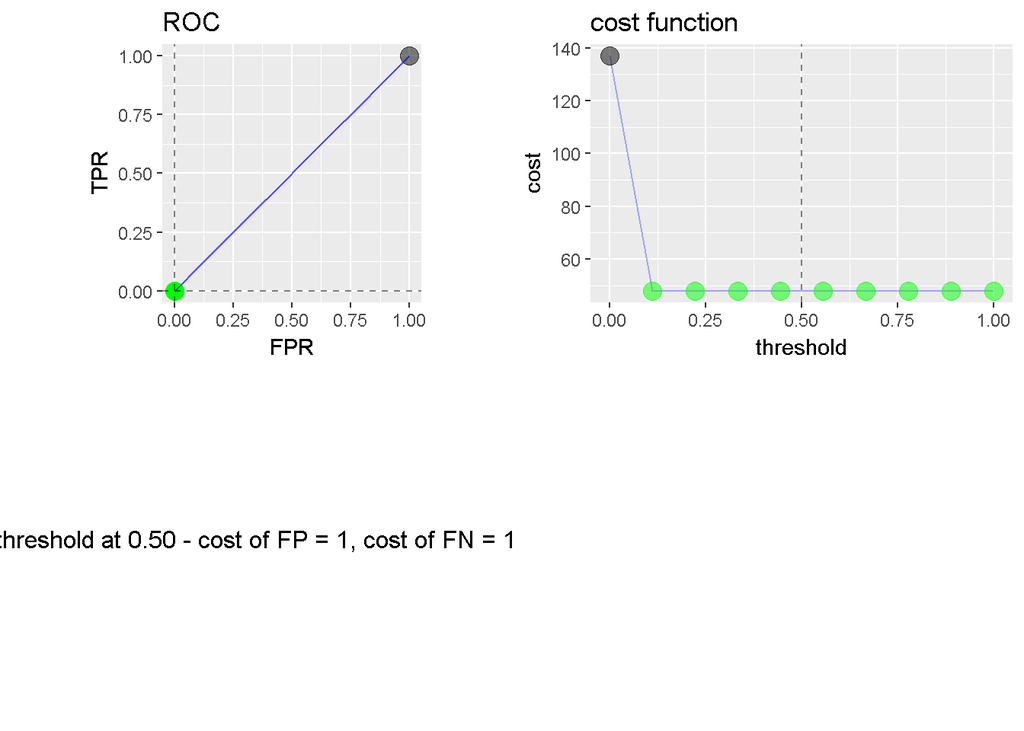

```r
roc=calculate_roc(dfSVM,1,1,n=10)
plot_roc(roc, 0.5, 1, 1)
```

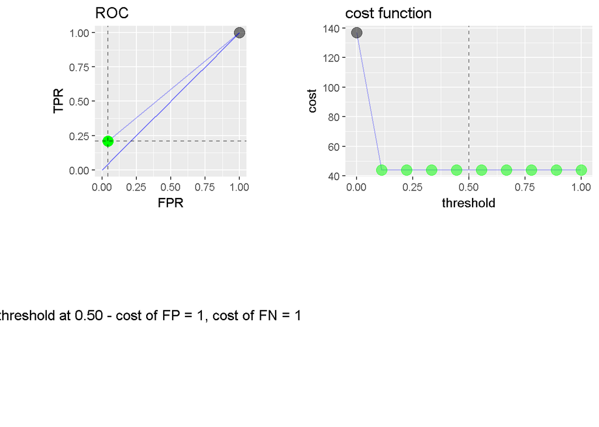

```r
roc=calculate_roc(dfNNET,1,1,n=10)
plot_roc(roc, 0.5, 1, 1)
```

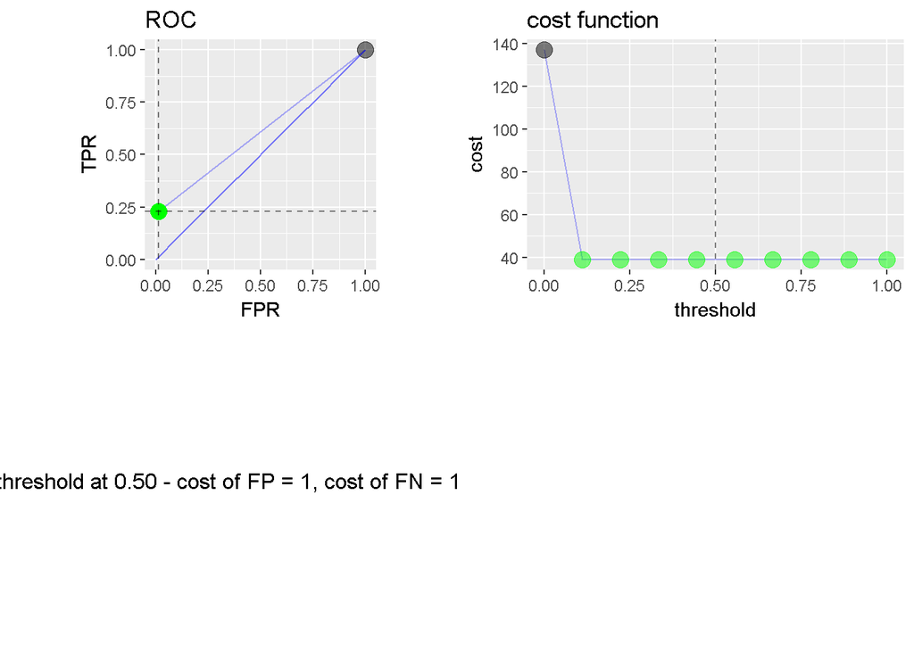

```r
roc=calculate_roc(dfGBM,1,1,n=10)
plot_roc(roc, 0.5, 1, 1)
```

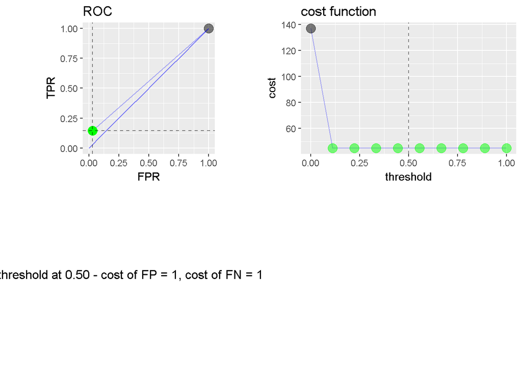

```r
roc=calculate_roc(dfGLM,1,1,n=10)
plot_roc(roc, 0.5, 1, 1)
```

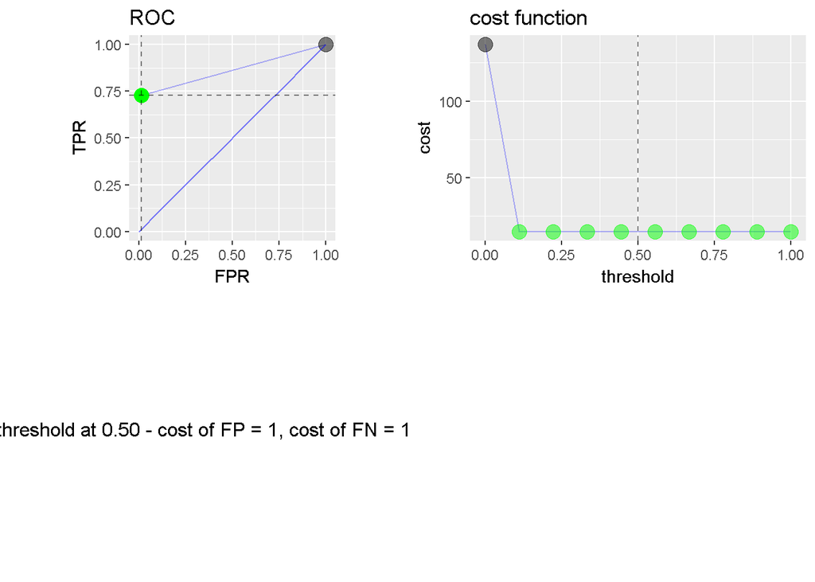

```r
roc=calculate_roc(dfRF,1,1,n=10)
plot_roc(roc, 0.5, 1, 1)
```

# Random Forest

Plot Confusion matrix: https://stats.stackexchange.com/questions/109079/confusion-between-caret-randomforest-predict-results-and-reported-model-perfor

```r
data("Affairs")

Affairs=Affairs%>%
  select(-gender,-children)%>%
  mutate(affairs=as.factor(affairs))%>%filter(affairs!=0)
Affairs$affairs=factor(Affairs$affairs,levels=c(1,2,3,7,12))

index <- sample(1:2,nrow(Affairs),replace=T,prob=c(0.7,0.3))
train = Affairs[index==1,]
test = Affairs[index==2,]

set.seed(825)
rfFit <- train(affairs ~ age+yearsmarried+religiousness+rating, data = train,
               method = "rf",
               trControl = fitControl,
               preProc = c("center", "scale"))
rfFit
```

```
## Random Forest
##
## 100 samples
##   4 predictor
##   5 classes: '1', '2', '3', '7', '12'
##
## Pre-processing: centered (4), scaled (4)
## Resampling: Cross-Validated (10 fold, repeated 5 times)
## Summary of sample sizes: 90, 91, 91, 90, 89, 91, ...
## Resampling results across tuning parameters:
##
##   mtry  Accuracy   Kappa
##   2     0.2906667  0.05013518
##   3     0.2766263  0.03618244
##   4     0.2786667  0.04385823
##
## Accuracy was used to select the optimal model using the largest value.
## The final value used for the model was mtry = 2.
```

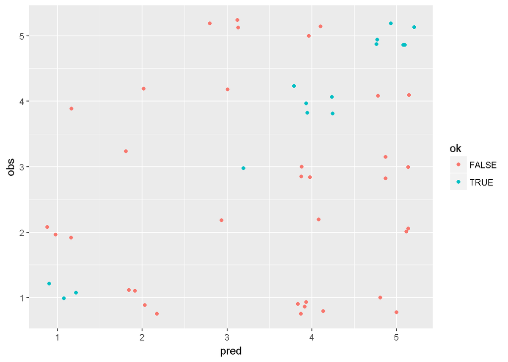

```r
results=as.data.frame(cbind(obs=test[,1],pred=predict(rfFit,test[,-1]%>%select(age,yearsmarried,religiousness,rating))))
results$ok=results$obs==results$pred

ggplot(results, aes(x = pred, y = obs,colour=ok)) +
  geom_jitter(position = position_jitter(width = 0.25, height = 0.25))
```

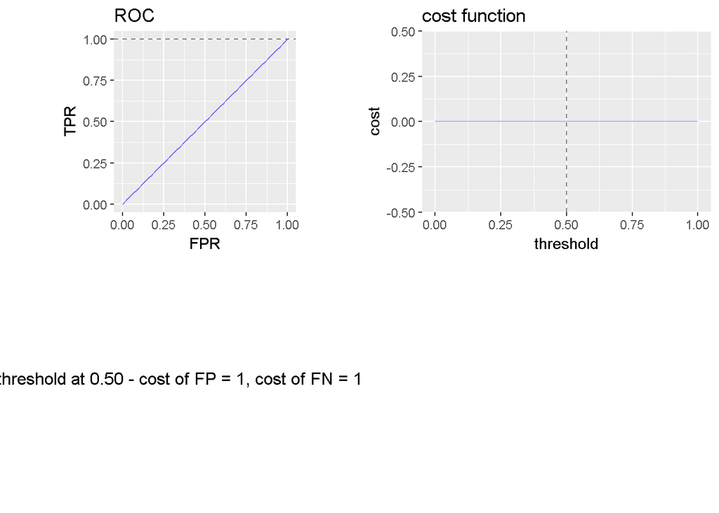

```r
roc=calculate_roc(results[,-3],1,1,n=100)
plot_roc(roc, 0.5, 1, 1)
```